# GoBi Exon-Skipping

Nabil Jabareen

10 November 2017

# GoBi: Excercise 1

The following plots show the maximum number of skipped Bases and skipped Exons in the human and mouse as commulative, relative frequency plots. Yeast (*Saccharomyces cerevisiae*) was also analysed, but it is not included in the graphs, because there were no exon skipping. Under the graphs are links to the genes with the most exon / bases skippings.

## Max skipped Bases

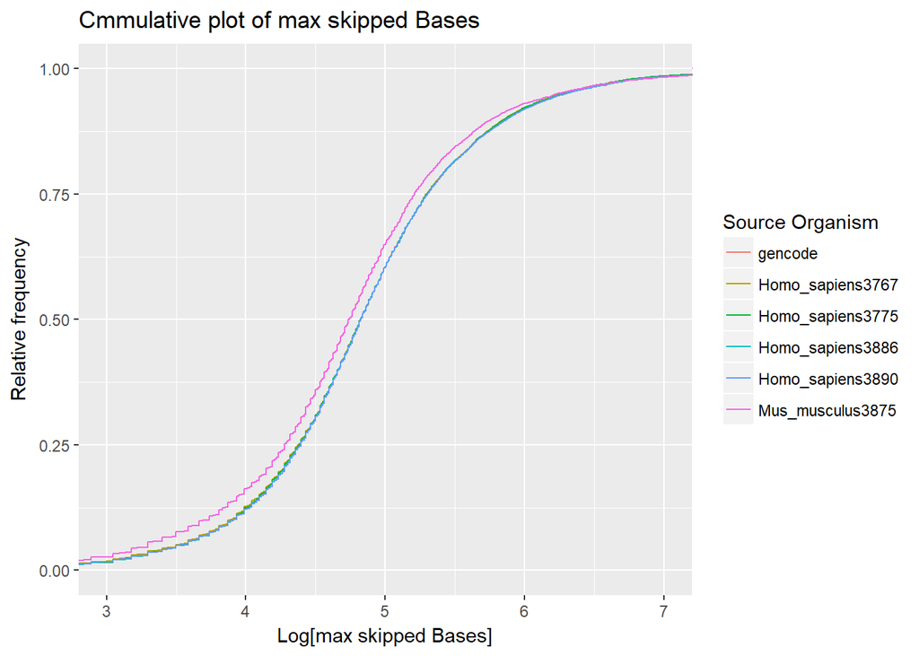

### Genes with most skipped Bases

ENSG00000155657 - *Homo sapiens* - Skipped Bases: 26106  
http://www.ensembl.org/Homo_sapiens/Gene/Summary?db=core;g=ENSG00000155657;r=2:178525989-178830802

ENSMUSG00000051747 - *Mus musculus* - Skipped Bases: 24843  
http://www.ensembl.org/Mus_musculus/Gene/Summary?db=core;g=ENSMUSG00000051747;r=2:76703980-76982547

ENSG00000283186 - *Homo sapiens* - Skipped Bases: 22134  
http://www.ensembl.org/Homo_sapiens/Gene/Idhistory?g=ENSG00000283186

ENSG00000145113 - *Homo sapiens* - Skipped Bases: 12875  
http://www.ensembl.org/Homo_sapiens/Gene/Summary?db=core;g=ENSG00000145113;r=3:195746765-195812277

ENSG00000164199 - *Homo sapiens* - Skipped Bases: 12530  
http://www.ensembl.org/Homo_sapiens/Gene/Summary?db=core;g=ENSG00000164199;r=5:90529344-91164437

ENSG00000187240 - *Homo sapiens* - Skipped Bases: 10182  
http://www.ensembl.org/Homo_sapiens/Gene/Summary?db=core;g=ENSG00000187240;r=11:103109431-103479863

ENSMUSG00000075249 - *Mus musculus* - Skipped Bases: 9659  
http://www.ensembl.org/Mus_musculus_A_J/Gene/Summary?db=core;g=MGP_AJ_G0025867;r=2:80381144-80444773

ENSG00000188738 - *Homo sapiens* - Skipped Bases: 9437  
http://www.ensembl.org/Homo_sapiens/Gene/Summary?db=core;g=ENSG00000188738;r=2:185738895-185833290

ENSG00000163092 - *Homo sapiens* - Skipped Bases: 9379  
http://www.ensembl.org/Homo_sapiens/Gene/Summary?db=core;g=ENSG00000163092;r=2:166888487-167259753

## Max skipped Exons

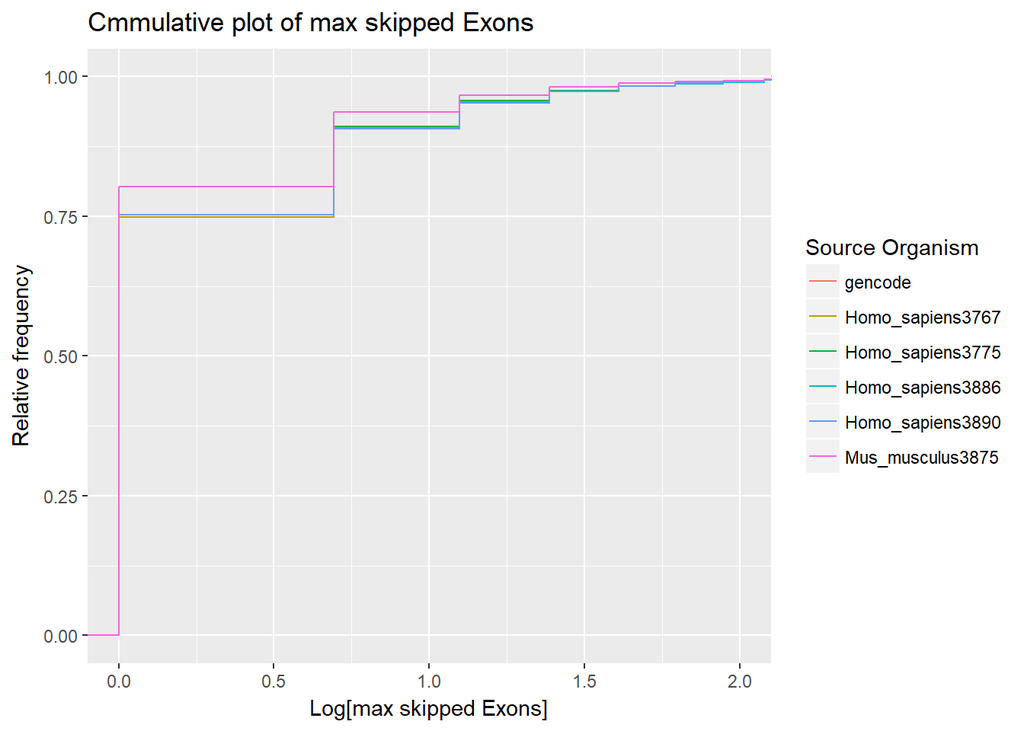

### Genes with most skipped Exons

ENSG00000155657 - *Homo sapiens* - Skipped Exons: 169  
http://www.ensembl.org/Homo_sapiens/Gene/Summary?db=core;g=ENSG00000155657;r=2:178525989-178830802

ENSMUSG00000051747 - *Mus musculus* - Skipped Exons: 154  
http://www.ensembl.org/Mus_musculus/Gene/Summary?db=core;g=ENSMUSG00000051747;r=2:76703980-76982547

ENSG00000283186 - *Homo sapiens* - Skipped Exons: 121  
http://www.ensembl.org/Homo_sapiens/Gene/Idhistory?g=ENSG00000283186

ENSG00000187240 - *Homo sapiens* - Skipped Exons: 70  
http://www.ensembl.org/Homo_sapiens/Gene/Summary?db=core;g=ENSG00000187240;r=11:103109431-103479863

ENSG00000271425 - *Homo sapiens* - Skipped Exons: 70  
http://www.ensembl.org/Homo_sapiens/Gene/Summary?db=core;g=ENSG00000271425;r=1:146064699-146144804

ENSG00000163386 - *Homo sapiens* - Skipped Exons: 60  
http://www.ensembl.org/Homo_sapiens/Gene/Idhistory?g=ENSG00000163386

ENSG00000164199 - *Homo sapiens* - Skipped Exons: 59  
http://www.ensembl.org/Homo_sapiens/Gene/Summary?db=core;g=ENSG00000164199;r=5:90529344-91164437

ENSG00000162825 - *Homo sapiens* - Skipped Exons: 56  
http://www.ensembl.org/Homo_sapiens/Gene/Summary?db=core;g=ENSG00000162825;r=1:145289900-145405778

ENSG00000186275 - *Homo sapiens* - Skipped Exons: 52  
http://www.ensembl.org/Homo_sapiens/Gene/Idhistory?g=ENSG00000186275

ENSG00000150995 - *Homo sapiens* - Skipped Exons: 42  
http://www.ensembl.org/Homo_sapiens/Gene/Summary?db=core;g=ENSG00000150995;r=3:4493348-4847840